# Oferta Académica | Serenity Studio & Enseñanza

# Serenity Studio & Enseñanza

### En Serenity, creemos en tus capacidades.

Descubre una formación diseñada para desarrollar tus habilidades, fortalecer tu confianza y prepararte para crecer profesionalmente en el área del bienestar, la estética y el masaje.

[Solicitar información](https://wa.link/pakhml)

# Diplomado en Terapia Manual

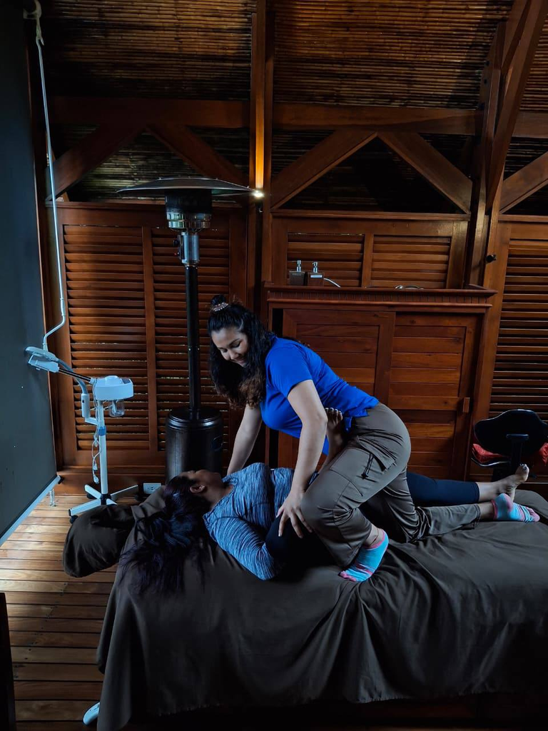

Diplomado

## Diplomado en Terapia Manual

**⏳ Duración:** 5 meses

**💰 Matrícula:** ₡18.000

**📅 Mensualidad:** ₡38.000

**👕 Incluye:** Uniforme.

🏅 Certificado avalado por FECOPROBE

### Aprenderás

- Masaje tailandés en camilla y tatami
- Shiatsu
- Masajes postoperatorios
- Lesiones deportivas
- Masaje geriátrico
- Pacientes encamados
- Neurosedante
- Masaje estético
- Ventosaterapia
- Reflexología avanzada
- Globos fríos
- Parafina reductiva y terapéutica
- Elaboración de casos clínicos

[Solicitar información](https://wa.link/pakhml)

# Talleres

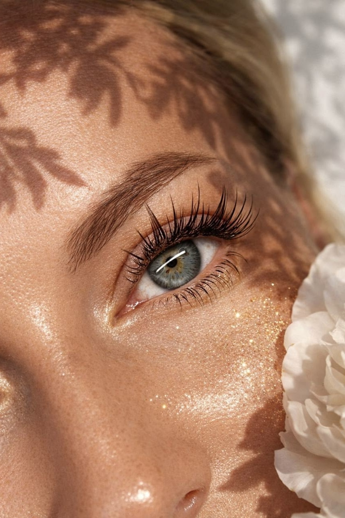

Taller

## Lifting de Pestañas

**⏳ Duración:** 4 horas

**💰 Inversión:** ₡18.000

🏅 Certificado avalado por FECOPROBE

**Ver más información**

#### Incluye

Refrigerio, Material PDF, algunos materiales de trabajo para la práctica y Certificado avalado por FECOPROBE

#### Materiales

Cubrebocas, guantes, toallas húmedas, una sábana, un paño de tamaño normal, bincha, microbrush o aplicadores, cepillos para pestañas, servilletas de cocina y pizeta

#### Requisitos

No se requiere experiencia. Se ocupa modelo. Reserva con la mitad. Sujeto a llenar cupo. No se hace devolución de dinero.

[Solicitar información](https://wa.link/pakhml)

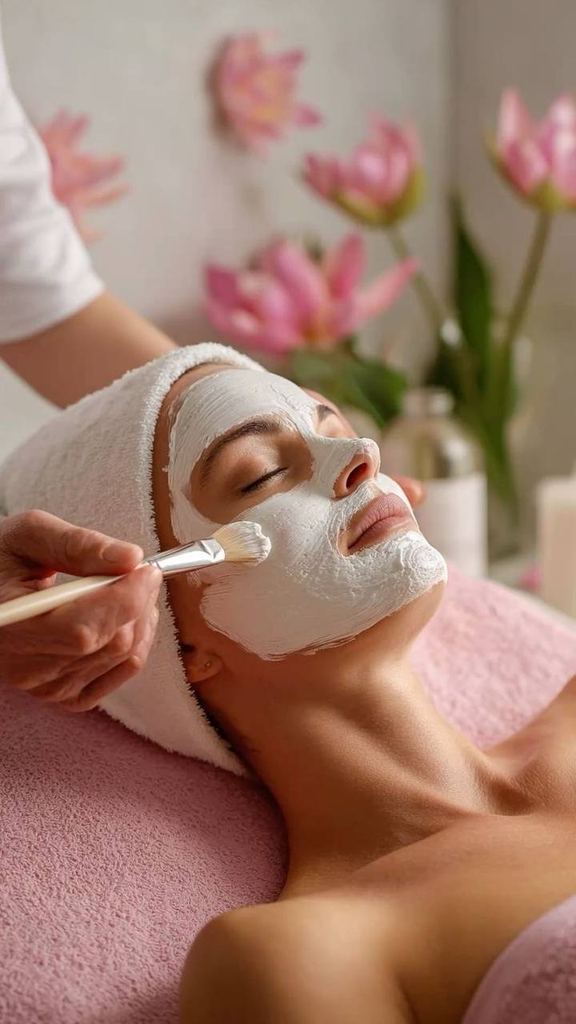

Taller

## Limpieza Facial Profunda

**⏳ Duración:** 4 horas

**💰 Inversión:** ₡25.000

🏅 Certificado avalado por FECOPROBE

**Ver más información**

#### Incluye

Refrigerio, Material PDF, algunos materiales de trabajo para la práctica y Certificado avalado por FECOPROBE

#### Materiales

Cubrebocas, guantes, toallas húmedas, una sábana, dos paños de tamaño normal, bincha, bowl grande y esponjas faciales

#### Requisitos

No se requiere experiencia. Se ocupa modelo. Reserva con la mitad. Sujeto a llenar cupo. No se hace devolución de dinero.

[Solicitar información](https://wa.link/pakhml)

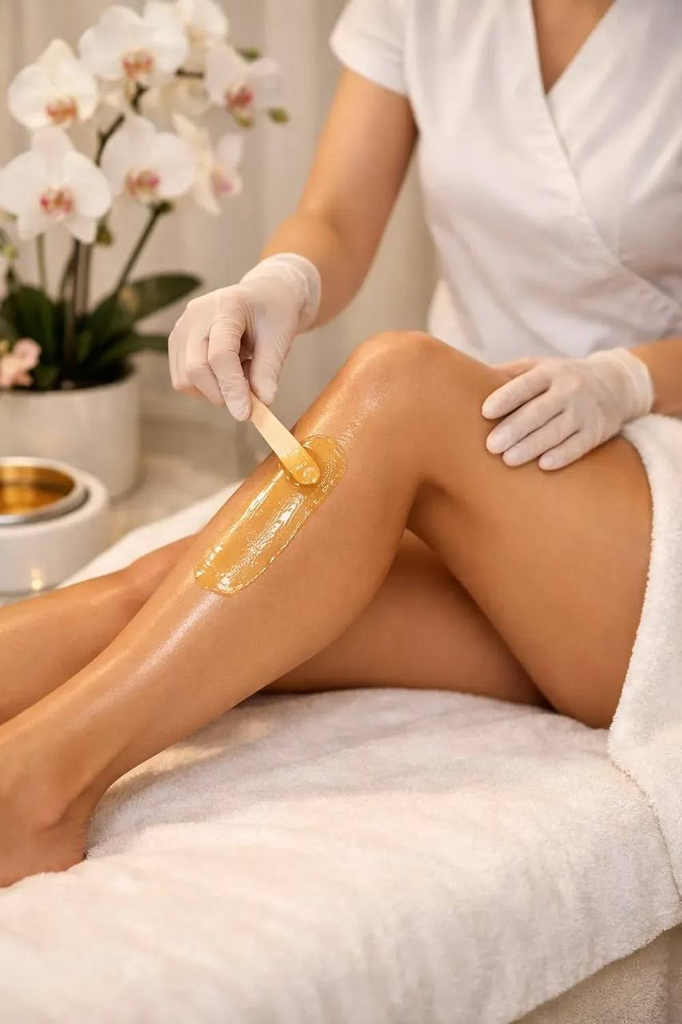

Taller

## Depilación con Cera

**⏳ Duración:** 4 horas

**💰 Inversión:** ₡30.000

🏅 Certificado avalado por FECOPROBE

**Ver más información**

#### Incluye

Refrigerio, Material PDF, algunos materiales de trabajo para la práctica y Certificado avalado por FECOPROBE

#### Materiales

Cubrebocas, guantes, una regla, toallas húmedas, una sábana, dos paños de tamaño normal y bincha

#### Requisitos

No se requiere experiencia. Se ocupa modelo. Reserva con la mitad. Sujeto a llenar cupo. No se hace devolución de dinero.

[Solicitar información](https://wa.link/pakhml)

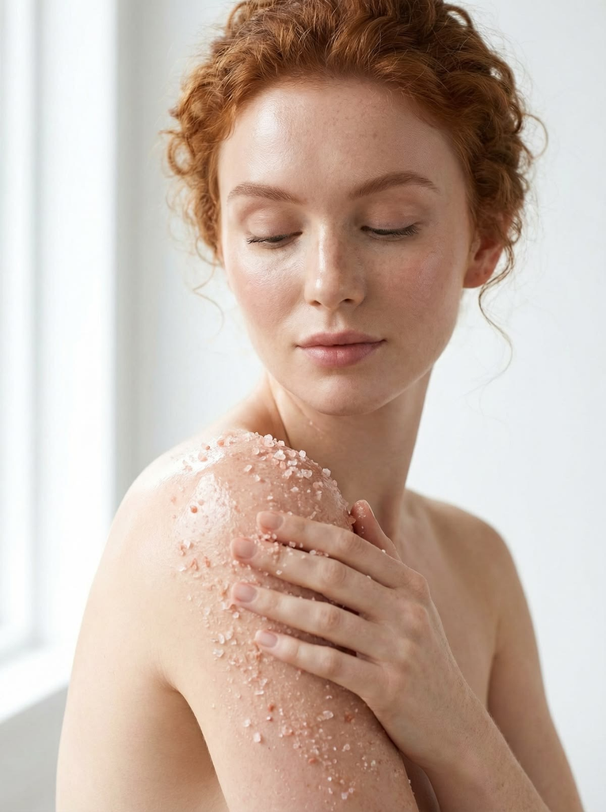

Taller

## Exfoliantes y Envolturas Corporales

**⏳ Duración:** 4 horas

**💰 Inversión:** ₡15.000

🏅 Certificado avalado por FECOPROBE

**Ver más información**

#### Incluye

Refrigerio, Material PDF y Certificado avalado por FECOPROBE

#### Materiales

Dos tazas medianas, recipientes para guardar productos, servilletas de cocina, mortero, rallador de cocina, crema corporal, aceite corporal, esencias corporales, cucharas pequeñas, tabla para picar pequeña y cuchillo pequeño

#### Requisitos

No se requiere experiencia. No se ocupa modelo. Reserva con la mitad. Sujeto a llenar cupo. No se hace devolución de dinero.

[Solicitar información](https://wa.link/pakhml)

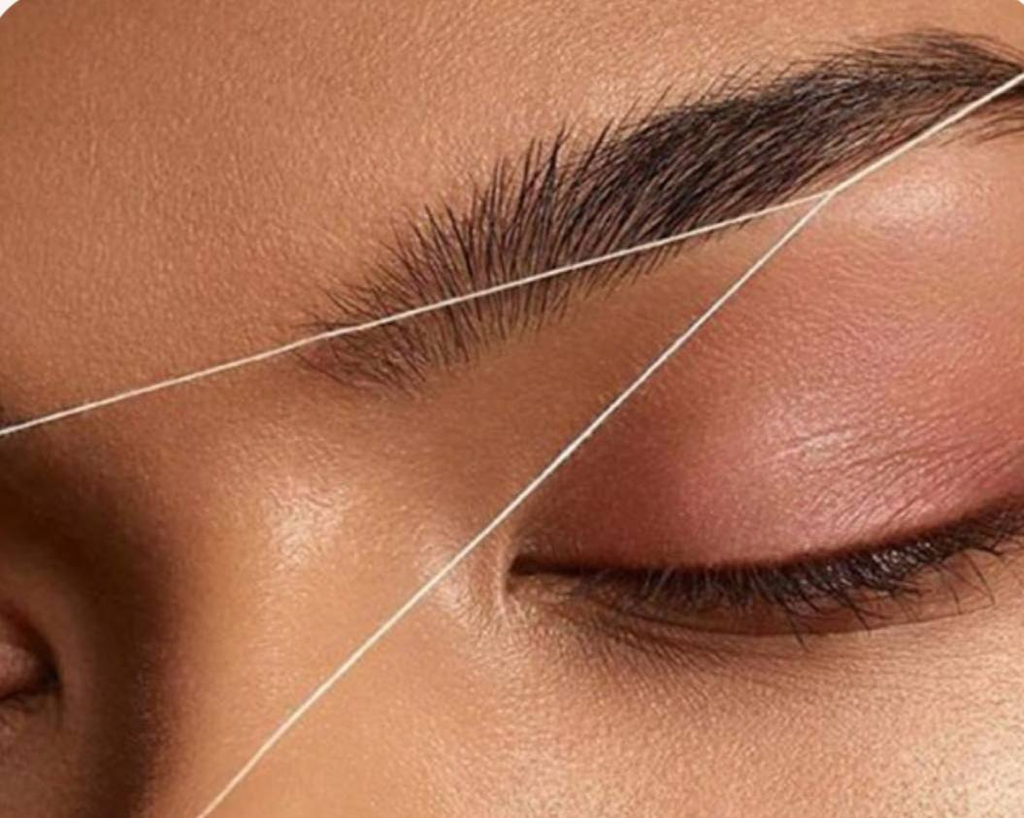

Taller

## Cejas Hindú

**⏳ Duración:** 4 horas

**💰 Inversión:** ₡30.000

🏅 Certificado avalado por FECOPROBE

**Ver más información**

#### Incluye

Refrigerio, Material PDF, kit de trabajo para práctica y llevar a casa, y Certificado avalado por FECOPROBE

#### Materiales

No requiere materiales adicionales especificados

#### Requisitos

No se requiere experiencia ni modelo. Reserva con la mitad. Sujeto a llenar cupo. No se hace devolución de dinero.

[Solicitar información](https://wa.link/pakhml)

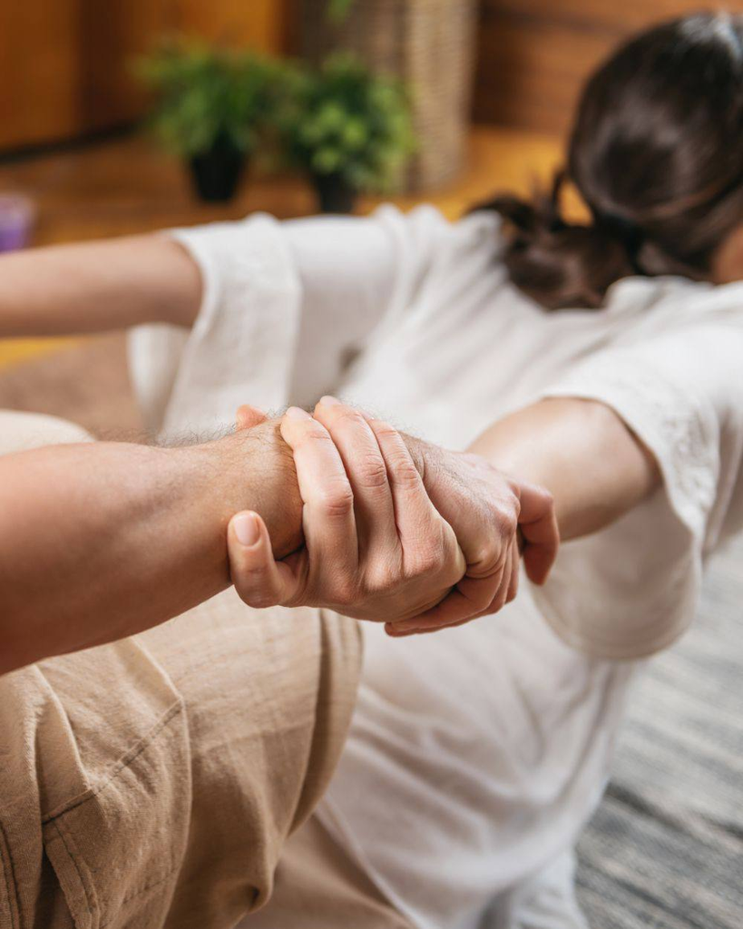

Taller

## Masaje Tailandés (Camilla y Tatami)

**⏳ Duración:** 5 horas

**💰 Inversión:** ₡25.000

🏅 Certificado avalado por FECOPROBE

**Ver más información**

#### Incluye

Refrigerio, Material PDF, tatami para la práctica en el aula y Certificado avalado por FECOPROBE

#### Materiales

Ropa cómoda

#### Requisitos

Se requiere modelo para la práctica.

[Solicitar información](https://wa.link/pakhml)

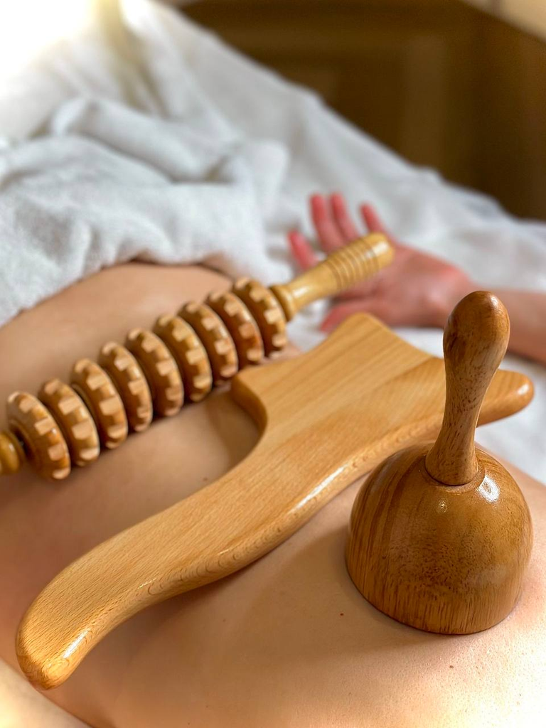

Taller

## Maderoterapia

**⏳ Duración:** 6 horas

**💰 Inversión:** ₡40.000

🏅 Certificado avalado por FECOPROBE

**Ver más información**

#### Incluye

Refrigerio, Material PDF, algunos materiales de trabajo para la práctica y Certificado avalado por FECOPROBE

#### Materiales

Guantes, toallas húmedas, una sábana, dos paños de tamaño normal, bowl mediano, kit de maderoterapia, venda elástica de 15 cm de ancho, centímetro y gel frío para masajes

#### Requisitos

Se requiere modelo para la práctica.

[Solicitar información](https://wa.link/pakhml)

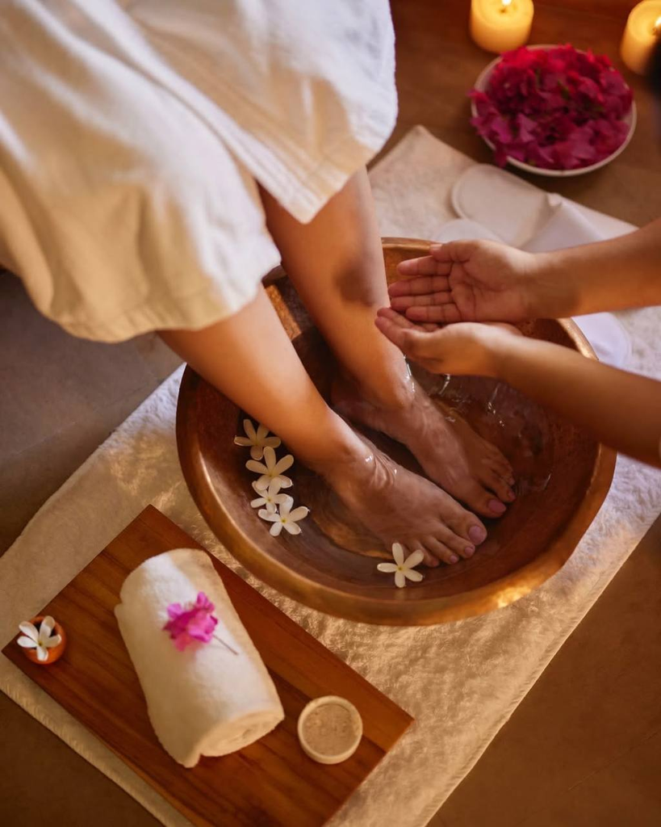

Taller

## Pedicure y Manicure Spa

**⏳ Duración:** 5 horas

**💰 Inversión:** ₡25.000

🏅 Certificado avalado por FECOPROBE

**Ver más información**

#### Incluye

Refrigerio, Material PDF, algunos materiales de trabajo para la práctica y Certificado avalado por FECOPROBE

#### Materiales

Tina plástica para pedicure, lima para pies, mascarilla hidratante de pies y manos, guantes, cubrebocas, dos paños normales, un paño mediano, un paño pequeño, toallas húmedas, plástico transparente de cocina y bowl mediano

#### Requisitos

Se requiere modelo para la práctica.

[Solicitar información](https://wa.link/pakhml)

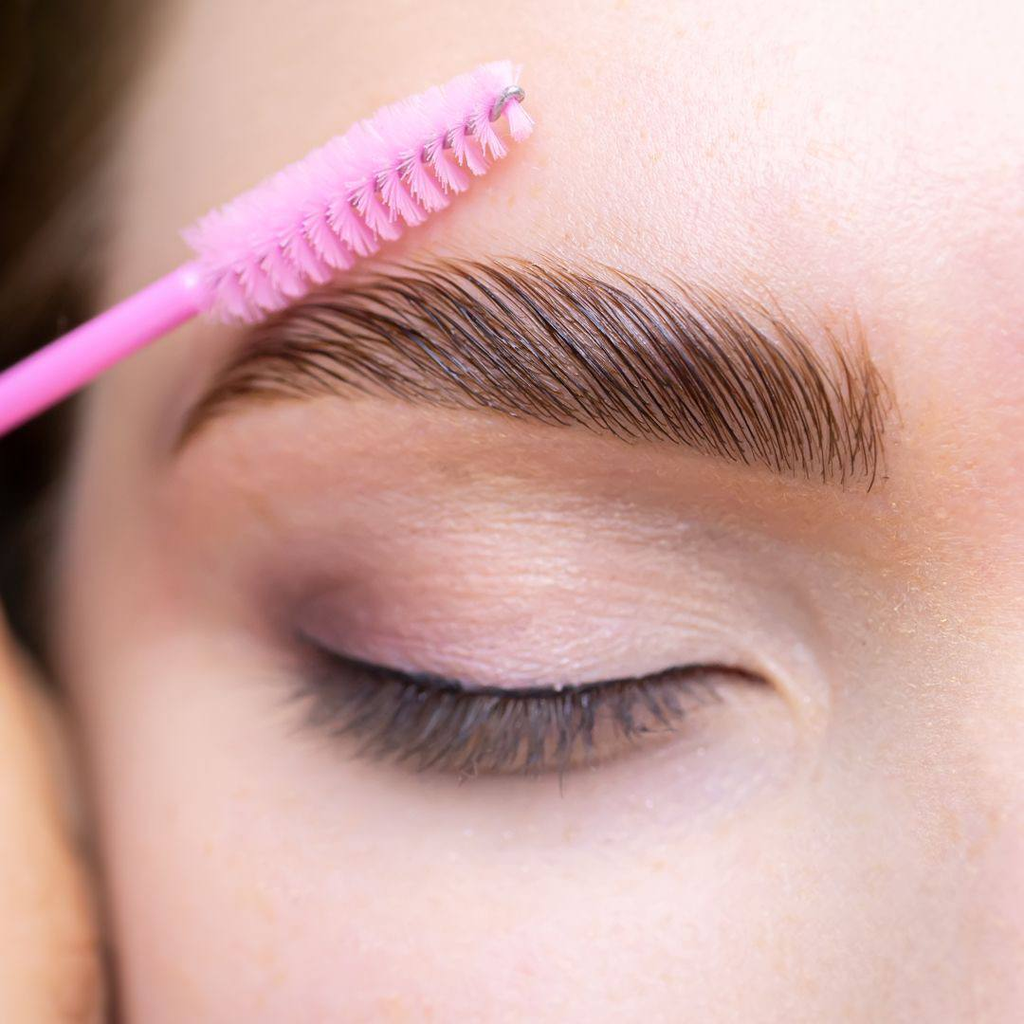

Taller

## Laminado y Henna en Cejas

**⏳ Duración:** 4 horas

**💰 Inversión:** ₡30.000

🏅 Certificado avalado por FECOPROBE

**Ver más información**

#### Incluye

Refrigerio, Material PDF, algunos materiales de trabajo para la práctica, Certificado avalado por FECOPROBE, lápiz de cejas, cepillos de cejas, microbrush, pads de algodón, pinceles, desmaquillante, perfiladores y pinzas

#### Materiales

Guantes, cubrebocas, una regla, toallas húmedas, una sábana, un paño de tamaño normal, una bincha, kit de laminado y henna

[Solicitar información](https://wa.link/pakhml)

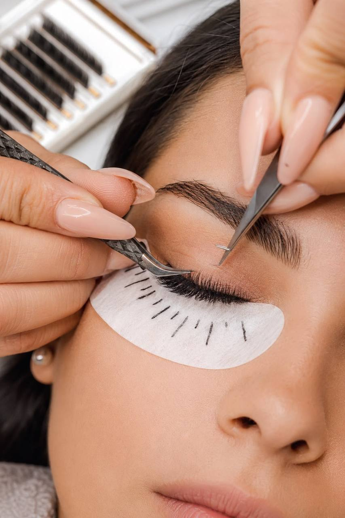

Taller

## Pestañas Pelo a Pelo

**⏳ Duración:** 6 clases de 4 horas

**💰 Inversión:** ₡120.000

🏅 Certificado avalado por FECOPROBE

**Ver más información**

#### Incluye

Refrigerio, Material PDF sobre técnica clásica, rusa, volúmenes con fibras tecnológicas, mapping, diseño y efectos; Certificado avalado por FECOPROBE; asesoría en la compra de materiales; taller teórico y práctico con modelos

#### Materiales

Los materiales específicos se adquieren con asesoría de la academia

#### Requisitos

Taller teórico y práctico con modelos. Opciones de pago: curso completo o pago de ₡20.000 antes de cada clase.

[Solicitar información](https://wa.link/pakhml)

# Cursos

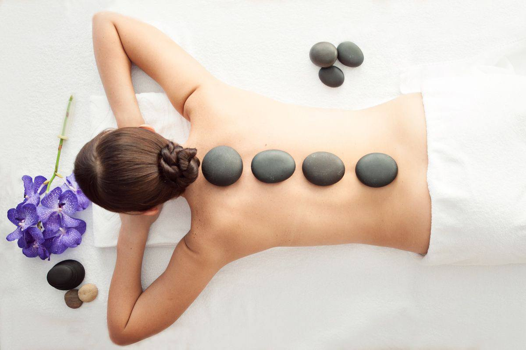

## 🌿 Módulo Relajante y Spa

**Duración:** 4 meses

**Matrícula:** ₡18.000

**Mensualidad:** ₡38.000

**Incluye:** Uniforme.

🏅 Certificado avalado por FECOPROBE

### Aprenderás

- Masaje reductivo
- Chocolate
- Lomi Lomi (Hawaiano)
- Facial (rostro)
- Ruso con miel
- Pindas aromáticas
- Piedras calientes
- Bambú
- Arcilla
- Aromaterapia
- Pedicure y Manicure Spa
- Exfoliación corporal
- Envolturas corporales

## 💙 Módulo Terapéutico

**Duración:** 4 meses

**Matrícula:** ₡18.000

**Mensualidad:** ₡38.000

**Incluye:** Uniforme.

🏅 Certificado avalado por FECOPROBE

### Aprenderás

- Masaje relajante
- Descontracturante
- Drenaje linfático
- Reflexología
- Embarazadas
- Infantil
- Esferas chinas
- Parálisis facial
- Criomasaje
- Deportivo
- Liberación miofascial
- Nervio ciático
- Masaje en silla

[Solicitar información del Curso](https://wa.link/pakhml)

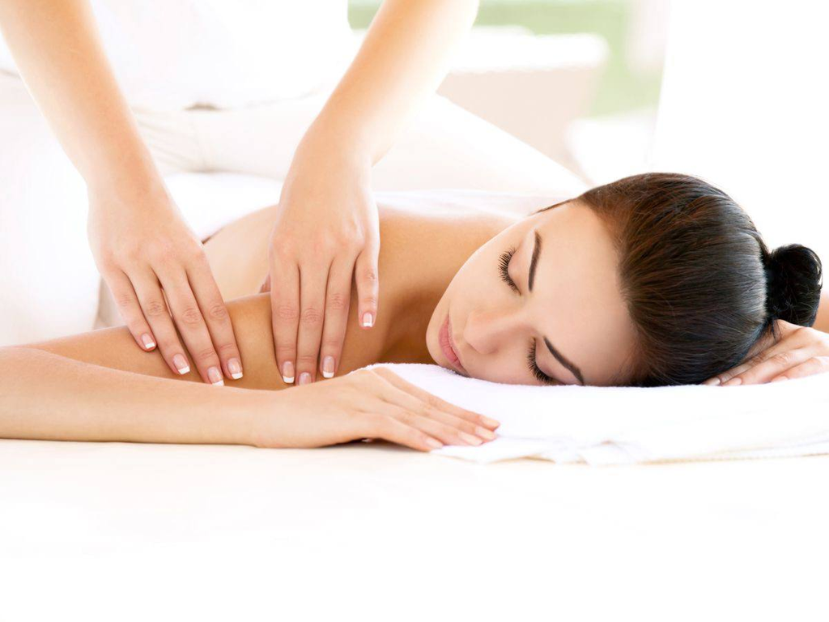

Curso

## Curso de Inglés para Masajistas

## Módulo 1 Introducción al Inglés

**Duración:** 4 meses

**Matrícula:** ₡18.000

**Mensualidad:** ₡38.000

**Incluye:** Uniforme.

🏅 Certificado avalado por FECOPROBE

### Temas

- Presentación personal.
- Números y precios.
- Meses y fechas.
- Artículos (A, An y The).

## Módulo 2 Énfasis en Masajes y SPA

**Duración:** 4 meses

**Matrícula:** ₡18.000

**Mensualidad:** ₡38.000

**Incluye:** Uniforme.

🏅 Certificado avalado por FECOPROBE

### Temas

- Vocabulario para masajistas.
- Músculos y huesos.
- Bebidas de SPA.
- Historial clínico.
- Atención al cliente.

[Solicitar información del Curso](https://wa.link/pakhml)

# ¿Por qué estudiar con Serenity?

### Modalidad Presencial y Virtual

Aprende de la forma que mejor se adapte a tu rutina. En Serenity te ofrecemos opciones flexibles para que puedas avanzar en tu formación sin dejar de lado tus responsabilidades personales, laborales o familiares.

### Instalaciones Equipadas

Estudia en un espacio preparado para practicar con confianza. Contamos con camillas, equipos e insumos adecuados para que cada clase se sienta cercana a la experiencia real de trabajo.

### Certificación

Cada curso, taller y diplomado está diseñado para respaldar tu crecimiento profesional con certificado avalado por FECOPROBE, fortaleciendo tu perfil y tus oportunidades en el área del bienestar y la estética.

### Enfoque Profesional

No solo aprenderás técnicas: también desarrollarás seguridad, criterio y herramientas para emprender, ofrecer mejores servicios y proyectarte con mayor confianza en el mercado laboral.

### Docencia Especializada

Aprende de la mano de la Lic. Diana Araya Moya, propietaria y docente de Serenity Studio & Enseñanza, en un ambiente cercano, humano y orientado a que descubras todo tu potencial.

# Contáctanos

### 📲 WhatsApp

6171-1832

[Escribir ahora](https://wa.link/pakhml)

### 📧 Correo

studioensenanzaserenity@gmail.com

### 📸 Instagram

@serenity_studio_ensenanza

[Ver Instagram](https://www.instagram.com/serenity_studio_ensenanza/)

### Dirección Académica

Lic. Diana Araya Moya

Propietaria y docente

## En Serenity, creemos en tus capacidades.

Formando profesionales con pasión, compromiso y excelencia.

© Serenity Studio & Enseñanza